# Quality_RScript

Venkata G

02-24-2024

Use control+Enter to run the code chunks on PC. Use command+Enter to run the code chunks on MAC.

## Load Packages

In this section, we install and load the necessary packages.

## Import Data

In this section, we import the necessary data for this lab.

# Quality Control Case

Everybody seems to disagree about just why so many parts have to be fixed or thrown away after they are produced. Some say that it’s the temperature of the production process, which needs to be held constant (within a reasonable range). Others claim that it’s clearly the density of the product, and that if we could only produce a heavier material, the problems would disappear. Then there is Ole the site manager, who has been warning everyone forever to take care not to push the equipment beyond its limits. This problem would be the easiest to fix, simply by slowing down the production rate; however, this would increase costs. Unfortunately, rate is the only variable that the manager can control. Interestingly, many of the workers on the morning shift think that the problem is “those inexperienced workers in the afternoon,” who, curiously, feel the same way about the morning workers.

Ever since the factory was automated, with computer network communication and bar code readers at each station, data have been piling up. After taking MGT314 class, you’ve finally decided to have a look. Your assistant aggregated the data by 4-hour blocks and then typed in the AM/PM variable, you found the following description of the variables:

*temp*: measures the temperature variability as a standard deviation during the time of measurement

*density*: indicates the density of the final product

*rate*: rate of production

*am*: 1 indicates morning and 0 afternoon

*defect*: average number of defects per 1000 produced

Do the following tasks and answer the questions below.

## Task 1: Explore your data

Explore the dataset using 5 functions: dim(), str(), colnames(), head() and tail().

```r
# Explore the dataset using 5 functions: dim(), str(), colnames(), head() and tail()

dim(quality)
```

```
## [1] 30  5
```

```r
str(quality)
```

```
## 'data.frame':    30 obs. of  5 variables:
##  $ temp   : num  0.97 2.85 2.95 2.84 1.84 2.05 1.5 2.48 2.23 3.02 ...
##  $ density: num  32.1 21.1 20.6 22.5 27.4 ...
##  $ rate   : num  178 254 273 273 211 ...
##  $ am     : int  0 1 1 1 0 1 0 0 0 1 ...
##  $ defect : num  0.2 47.9 50.9 49.7 11 15.6 5.5 37.4 27.8 58.7 ...
```

```r
colnames(quality)
```

```
## [1] "temp"    "density" "rate"    "am"      "defect"
```

```r
head(quality)
```

```
##   temp density  rate am defect
## 1 0.97   32.08 177.7  0    0.2
## 2 2.85   21.14 254.1  1   47.9
## 3 2.95   20.65 272.6  1   50.9
## 4 2.84   22.53 273.4  1   49.7
## 5 1.84   27.43 210.8  0   11.0
## 6 2.05   25.42 236.1  1   15.6
```

```r
tail(quality)
```

```
##    temp density  rate am defect
## 25 2.92   22.50 260.0  1   55.4
## 26 2.44   23.47 236.0  0   36.7
## 27 1.87   26.51 237.3  0   24.5
## 28 1.45   30.70 221.0  1    2.8
## 29 2.82   22.30 253.2  1   60.8
## 30 1.74   28.47 207.9  0   10.5
```

## Task 2: Run descriptive statistics

Compute correlation between defect and temp, between defect and density, between defect and rate. Feel free to use dplyr functions if needed.

```r
# Descriptive stats for continuous variables

quality %>%
  summarise(
    cor_defect_temp = cor(defect, temp),
    cor_defect_densitty = cor(defect, density),
    cor_defect_rate = cor(defect, rate)
  )
```

```
##   cor_defect_temp cor_defect_densitty cor_defect_rate
## 1       0.9290726           -0.923365       0.8853499
```

**Question 2**: what do we learn about the data?

1. There is a strong positive correlation (0.93) between the defect rate and temperature (temp). This shows that as the temperature increases, the defect rate tends to increase.
2. There is a strong negative correlation (-0.92) between the defect rate and density of the final product. This shows that if density is more that tends to lower defect rates.
3. There is a strong positive correlation (0.89) between the defect rate and production rate (rate). This shows that higher production rates are associated with higher defect rates.

## Task 3: Identify response and predictor and plot the scatter plot

Because we want to learn what variables impact the defect and how they impact the defect, the response (dependent variable) should be defect, and the 3 potential candidates of numerical predictors (independent variables) are temp, density, and rate.

Next, use ggplot() from ggplot2 package to create a scatter plot for the response and ONE of the predictors by YOUR CHOICE. You need to set defect as the y axis and the predictor you choose as the x axis.

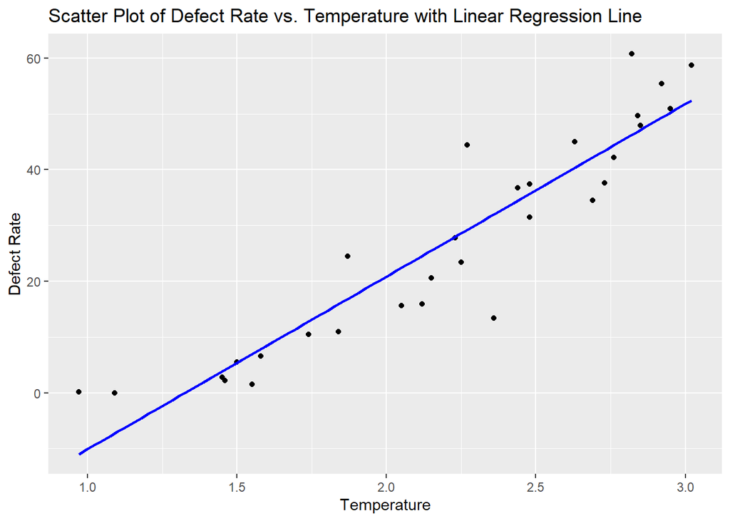

```r
# scatter plot of response vs. the predictor you choose. Set defect as the y axis and the predictor as the x axis.
ggplot(quality, aes(x = temp, y = defect)) +
  geom_point() +
  geom_smooth(method = "lm", se = FALSE, color = "blue") +
  labs(x = "Temperature", y = "Defect Rate") +
  ggtitle("Scatter Plot of Defect Rate vs. Temperature with Linear Regression Line")
```

**Question 3** What does the scatter plot show? Write one line for the relationship between the response and the predictor.

The scatter plot of defect versus temperature (temp) shows a strong positive correlation, where the data points align closely along a linear trend line, indicating that as temperature variability increases, the number of defects also tends to increase..

## Task 4: Simple Linear Regression

Use the response and the predictor you selected in Task 3 to run regression analyses as instructed below.

Use lm() to run a regression analysis on the predictor you selected in Task 3 as X and the response as Y. The, use function summary() to summarize the regression analysis.

```r
reg_temp_def <- lm(defect ~ temp, data = quality)
summary(reg_temp_def)
```

```
##
## Call:
## lm(formula = defect ~ temp, data = quality)
##
## Residuals:
##      Min       1Q   Median       3Q      Max
## -18.5937  -4.9138  -0.6179   4.2113  15.1887
##
## Coefficients:
##             Estimate Std. Error t value Pr(>|t|)
## (Intercept)  -40.966      5.295  -7.736 1.99e-08 ***
## temp          30.915      2.326  13.291 1.29e-13 ***
## ---
## Signif. codes:  0 '***' 0.001 '**' 0.01 '*' 0.05 '.' 0.1 ' ' 1
##
## Residual standard error: 7.308 on 28 degrees of freedom
## Multiple R-squared:  0.8632, Adjusted R-squared:  0.8583
## F-statistic: 176.6 on 1 and 28 DF,  p-value: 1.29e-13
```

**Question 4**: How do you interpret the results? Interpret (1) the coefficient estimates, (2) p-value for beta1, (3) R-squared, and (4) p-value for F-statistics.

1. The coefficient for the temperature variability (temp) is 30.915. This indicates that for every one unit increase in temperature variability, the defect rate is estimated to increase by 30.915 units.
2. The p-value associated with the coefficient for temp is very small (1.29e-13), which is less than the typical significance level of 0.05.Therefore, we can conclude that temperature variability (temp) has a statistically significant effect on the defect rate.
3. The R-squared value is 0.8632. This means that approximately 86.32% of the variability in the defect rate can be explained by the linear regression model with temperature variability as the predictor.
4. The p-value associated with the F-statistic (1.29e-13) is very small. Therefore, the model as a whole is statistically significant, and at least one of the predictors has a non-zero effect on the defect rate.